# Nunn (Harvard University) - replication & critique

Edoardo Falchi

28/9/2021

# 1 Description

This project concerns replicating the main findings (plots and tables) from the paper

> Nunn N. The Long Term Effects of Africa’s Slave Trades. Quarterly Journal of Economics. 2008; 123 (1) : 139-176

What this project does not include is questioning the author’s aurgumentations. For a detailed evidence examination please refer to the author’s paper which he made freely available on his [Harvard webiste](https://scholar.harvard.edu/nunn/publications/long-term-effects-africas-slave-trades) along with the [dataset](https://scholar.harvard.edu/nunn/pages/data-0).

However, in the Critique section, I point out some flaws which I think weaken Nunn’s results and some improvements which I personally suggest are woth considering.

To start off, Nathan Nunn’s research question is:

> Can part of Africa’s current underdevelopment be explained by its slave trades? To explore this question, I use data from shipping records and historical documents reporting slave ethnicities to construct estimates of the number of slaves exported from each country during Africa’s slave trades. I find a robust negative relationship between the number of slaves exported from a country and current economic performance. To better understand if the relationship is causal, I examine the historical evidence on selection into the slave trades and use **instrumental variables**. Together the evidence suggests that the slave trades had an adverse effect on economic development.

# 2 Replication

The Dataset is made up of 52 entries, one for each african State, and 39 variables.

```r
slave_data <- read_dta("slave_trade_QJE.dta")
kable(slave_data[1:5,])
```

| isocode | country | ln_maddison_pcgdp2000 | ln_export_area | ln_export_pop | colony0 | colony1 | colony2 | colony3 | colony4 | colony5 | colony6 | colony7 | abs_latitude | longitude | rain_min | humid_max | low_temp | ln_coastline_area | island_dum | islam | legor_fr | legor_uk | region_n | region_s | region_w | region_e | region_c | ln_avg_gold_pop | ln_avg_oil_pop | … |
| --- | --- | --- | --- | --- | --- | --- | --- | --- | --- | --- | --- | --- | --- | --- | --- | --- | --- | --- | --- | --- | --- | --- | --- | --- | --- | --- | --- | --- | --- | --- |
| AGO | Angola | 6.670766 | 7.967493 | 14.399250 | 0 | 0 | 0 | 1 | 0 | 0 | 0 | 0 | 8 | 17.54142 | 0 | 78 | 14 | 0.2468601 | 0 | 0 | 1 | 0 | 0 | 0 | 0 | 0 | 1 | -6.614335 | 0.643126 | … |
| BDI | Burundi | 6.354370 | 1.140843 | 4.451658 | 0 | 0 | 0 | 0 | 1 | 0 | 0 | 0 | 16 | 29.88722 | 5 | 82 | 17 | -4.6051702 | 0 | 1 | 1 | 0 | 0 | 0 | 0 | 1 | 0 | -2.633923 | -9.210340 | … |
| BEN | Benin | 7.187657 | 8.304137 | 13.308970 | 0 | 0 | 1 | 0 | 0 | 0 | 0 | 0 | 6 | 2.34264 | 13 | 78 | 18 | 0.0684028 | 0 | 13 | 1 | 0 | 0 | 0 | 1 | 0 | 0 | -13.815511 | -3.531555 | … |
| BFA | Burkina Faso | 6.748760 | 6.413822 | 11.724286 | 0 | 0 | 1 | 0 | 0 | 0 | 0 | 0 | 12 | -1.74292 | 0 | 67 | 9 | -4.6051702 | 0 | 42 | 1 | 0 | 0 | 0 | 1 | 0 | 0 | -2.164328 | -9.210340 | … |
| BWA | Botswana | 8.377471 | -2.302585 | 3.912023 | 0 | 1 | 0 | 0 | 0 | 0 | 0 | 0 | 24 | 23.82042 | 0 | 74 | -4 | -4.6051702 | 0 | 0 | 0 | 1 | 0 | 1 | 0 | 0 | 0 | -3.705090 | -9.210340 | … |

## 2.1 Figure III: plot relationship between GDP and slave exports

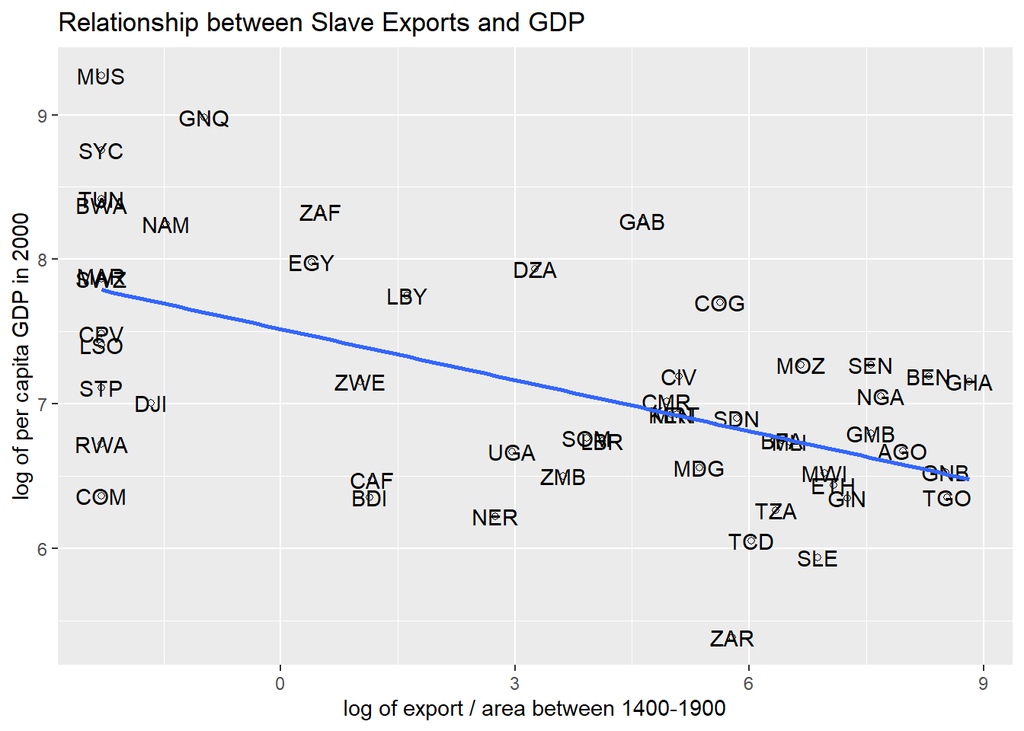

```r
ggplot(slave_data, aes(x=ln_export_area, y=ln_maddison_pcgdp2000))+
  geom_point(shape=1)+
  geom_text(label=slave_data$isocode)+
  geom_smooth(method=lm, se=FALSE)+
  ggtitle("Relationship between Slave Exports and GDP")+
  xlab("log of export / area between 1400-1900")+
  ylab("log of per capita GDP in 2000")
```

## 2.2 Table III: get OLS estimates of slaves/area over various specifications

```r
##only colonizer effects
ols1<- lm(ln_maddison_pcgdp2000~ln_export_area+colony1+colony2+colony3+
            colony4+colony5+colony6+colony7, data=slave_data)
##colonizer and geographic effects
ols2<- lm(ln_maddison_pcgdp2000~ln_export_area+abs_latitude+longitude+
            rain_min+humid_max+low_temp+ln_coastline_area+
            colony1+colony2+colony3+
            colony4+colony5+colony6+colony7, data=slave_data)
##colonizer and geographic effects w/o islands and North countries
remove_isl_and_north<- c('Morocco','Algeria','Tunisia','Libya','Egypt','Seychelles',
                         'Mauritius','Comoros','Sao Tome & Principe','Cape Verde Islands')
restricted_sample<-slave_data[!slave_data$country %in% remove_isl_and_north,]
ols3<- lm(ln_maddison_pcgdp2000~ln_export_area+abs_latitude+longitude+
            rain_min+humid_max+low_temp+ln_coastline_area+
            colony1+colony2+colony3+
            colony4+colony5+colony6+colony7, data=restricted_sample)
##additional controls: island fixed effect, North Africa fixed effect, French legal origin, percent islamic
ols4<- lm(ln_maddison_pcgdp2000~ln_export_area+abs_latitude+longitude+
            rain_min+humid_max+low_temp+ln_coastline_area+region_n+legor_fr+island_dum+islam+
            colony1+colony2+colony3+
            colony4+colony5+colony6+colony7, data=slave_data)
##additional controls: log of the annual average per capita production of gold, oil, diamonds
ols5<- lm(ln_maddison_pcgdp2000~ln_export_area+abs_latitude+longitude+
            rain_min+humid_max+low_temp+ln_coastline_area+region_n+legor_fr+island_dum+islam+
            ln_avg_gold_pop+ln_avg_oil_pop+ln_avg_all_diamonds_pop+
            colony1+colony2+colony3+
            colony4+colony5+colony6+colony7, data=slave_data)
##all control variables and drop islands and North African countries
ols6<- lm(ln_maddison_pcgdp2000~ln_export_area+abs_latitude+longitude+
            rain_min+humid_max+low_temp+ln_coastline_area+region_n+legor_fr+island_dum+islam+
            ln_avg_gold_pop+ln_avg_oil_pop+ln_avg_all_diamonds_pop+
            colony1+colony2+colony3+
            colony4+colony5+colony6+colony7, data=restricted_sample)
```

```r
# generate table
stargazer(ols1,ols2,ols3,ols4,ols5,ols6,
          header = FALSE,
          digits = 3,
          title="Relationship between Slave Exports and Income",
          type = "html",
          dep.var.labels.include = FALSE,
          dep.var.caption =
            "Dependent variable is log real per capita GDP in 2000, ln y",
          omit=c('colony1','colony2','colony3','colony4','colony5','colony6','colony7','Constant'),
          add.lines=list(c('Colonizer fixed effects',"Yes","Yes","Yes","Yes","Yes","Yes")))
```

**Relationship between Slave Exports and Income**

|  | Dependent variable is log real per capita GDP in 2000, ln y |  |  |  |  |  |
| --- | --- | --- | --- | --- | --- | --- |
|  | (1) | (2) | (3) | (4) | (5) | (6) |
| ln_export_area | -0.112*** | -0.076** | -0.108*** | -0.085** | -0.103*** | -0.128*** |
|  | (0.024) | (0.029) | (0.037) | (0.035) | (0.034) | (0.034) |
| abs_latitude |  | 0.016 | -0.005 | 0.019 | 0.023 | 0.006 |
|  |  | (0.017) | (0.020) | (0.018) | (0.017) | (0.017) |
| longitude |  | 0.0005 | -0.007 | -0.004 | -0.004 | -0.009 |
|  |  | (0.005) | (0.006) | (0.006) | (0.005) | (0.006) |
| rain_min |  | -0.001 | 0.008 | 0.0001 | -0.001 | -0.002 |
|  |  | (0.007) | (0.008) | (0.007) | (0.006) | (0.008) |
| humid_max |  | 0.009 | 0.008 | 0.009 | 0.015 | 0.013 |
|  |  | (0.012) | (0.012) | (0.012) | (0.011) | (0.010) |
| low_temp |  | -0.019 | -0.039 | -0.005 | -0.015 | -0.037 |
|  |  | (0.028) | (0.028) | (0.027) | (0.026) | (0.025) |
| ln_coastline_area |  | 0.085** | 0.092** | 0.095** | 0.082** | 0.083** |
|  |  | (0.039) | (0.042) | (0.042) | (0.040) | (0.037) |
| region_n |  |  |  | 0.382 | -0.304 |  |
|  |  |  |  | (0.484) | (0.517) |  |
| legor_fr |  |  |  | 0.755 | 0.643 | -0.141 |
|  |  |  |  | (0.503) | (0.470) | (0.734) |
| island_dum |  |  |  | -0.398 | -0.150 |  |
|  |  |  |  | (0.529) | (0.516) |  |
| islam |  |  |  | -0.008*** | -0.006* | -0.003 |
|  |  |  |  | (0.003) | (0.003) | (0.003) |
| ln_avg_gold_pop |  |  |  |  | 0.011 | 0.014 |
|  |  |  |  |  | (0.017) | (0.015) |
| ln_avg_oil_pop |  |  |  |  | 0.078*** | 0.088*** |
|  |  |  |  |  | (0.027) | (0.025) |
| ln_avg_all_diamonds_pop |  |  |  |  | -0.039 | -0.048 |
|  |  |  |  |  | (0.043) | (0.041) |
| Colonizer fixed effects | Yes | Yes | Yes | Yes | Yes | Yes |
| Observations | 52 | 52 | 42 | 52 | 52 | 42 |
| R<sup>2</sup> | 0.505 | 0.601 | 0.633 | 0.709 | 0.773 | 0.797 |
| Adjusted R<sup>2</sup> | 0.413 | 0.450 | 0.463 | 0.551 | 0.615 | 0.639 |
| Residual Std. Error | 0.632 (df = 43) | 0.612 (df = 37) | 0.530 (df = 28) | 0.553 (df = 33) | 0.512 (df = 30) | 0.435 (df = 23) |
| F Statistic | 5.484*** (df = 8; 43) | 3.982*** (df = 14; 37) | 3.716*** (df = 13; 28) | 4.473*** (df = 18; 33) | 4.874*** (df = 21; 30) | 5.027*** (df = 18; 23) |
| *Note:* | p<0.1; p<0.05; p<0.01 |  |  |  |  |  |

## 2.3 Figure IV: plot relationship between Population Density (as proxy for economic prosperity) and Slave Exports

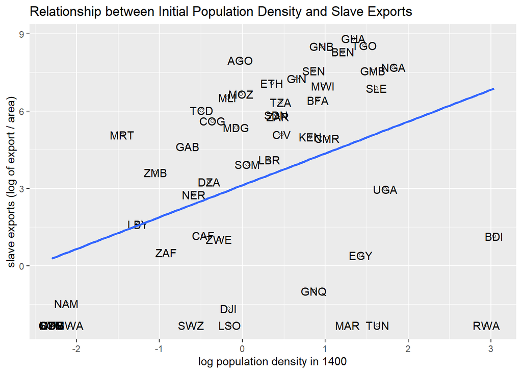

```r
ggplot(slave_data, aes(x=ln_pop_dens_1400, y=ln_export_area))+
  geom_point(shape=1)+
  geom_text(label=slave_data$isocode)+
  geom_smooth(method=lm, se=FALSE)+
  ggtitle("Relationship between Initial Population Density and Slave Exports")+
  xlab("log population density in 1400")+
  ylab("slave exports (log of export / area)")
```

## 2.4 Table IV: get IV 2SLS estimates of slaves/area over various specifications

```r
#SECOND STAGE

##w/o control variables
ivreg1<-ivreg(ln_maddison_pcgdp2000~ln_export_area|saharan_distance_minimum+
                atlantic_distance_minimum+indian_distance_minimum+red_sea_distance_minimum, data=slave_data)
##includes colonizer fixed effects
ivreg2<-ivreg(ln_maddison_pcgdp2000~ln_export_area+colony1+colony2+colony3+
                colony4+colony5+colony6+colony7|colony1+colony2+colony3+
                colony4+colony5+colony6+colony7+saharan_distance_minimum+
                atlantic_distance_minimum+indian_distance_minimum+red_sea_distance_minimum, data=slave_data)
##includes colonizer fixed effects and geographic controls
ivreg3<-ivreg(ln_maddison_pcgdp2000~ln_export_area+abs_latitude+longitude+
                rain_min+humid_max+low_temp+ln_coastline_area+
                colony1+colony2+colony3+
                colony4+colony5+colony6+colony7|abs_latitude+longitude+
                rain_min+humid_max+low_temp+ln_coastline_area+
                colony1+colony2+colony3+
                colony4+colony5+colony6+colony7+
                saharan_distance_minimum+
                atlantic_distance_minimum+indian_distance_minimum+red_sea_distance_minimum, data=slave_data)
##includes colonizer fixed effects and geographic controls, but the sample excludes islands and North African countries.
ivreg4<-ivreg(ln_maddison_pcgdp2000~ln_export_area+abs_latitude+longitude+
                rain_min+humid_max+low_temp+ln_coastline_area+
                colony1+colony2+colony3+
                colony4+colony5+colony6+colony7|abs_latitude+longitude+
                rain_min+humid_max+low_temp+ln_coastline_area+
                colony1+colony2+colony3+
                colony4+colony5+colony6+colony7+
                saharan_distance_minimum+
                atlantic_distance_minimum+indian_distance_minimum+red_sea_distance_minimum, data=restricted_sample)

#FIRST STAGE
stage1_1<-lm(ln_export_area~saharan_distance_minimum+
               atlantic_distance_minimum+indian_distance_minimum+red_sea_distance_minimum, data=slave_data)
stage1_2<-lm(ln_export_area~saharan_distance_minimum+
               atlantic_distance_minimum+indian_distance_minimum+red_sea_distance_minimum+colony1+colony2+colony3+
               colony4+colony5+colony6+colony7, data=slave_data)
stage1_3<-lm(ln_export_area~saharan_distance_minimum+
               atlantic_distance_minimum+indian_distance_minimum+red_sea_distance_minimum+colony1+colony2+colony3+
               colony4+colony5+colony6+colony7+abs_latitude+longitude+
               rain_min+humid_max+low_temp+ln_coastline_area, data=slave_data)
stage1_4<-lm(ln_export_area~saharan_distance_minimum+
               atlantic_distance_minimum+indian_distance_minimum+red_sea_distance_minimum+colony1+colony2+colony3+
               colony4+colony5+colony6+colony7+abs_latitude+longitude+
               rain_min+humid_max+low_temp+ln_coastline_area, data=restricted_sample)

pvH_1<-round(summary(ivreg1, diagnostics = TRUE)$diagnostics[2,4], digits=2)#Hausman test pvalue
pvH_2<-round(summary(ivreg2, diagnostics = TRUE)$diagnostics[2,4], digits=2)
pvH_3<-round(summary(ivreg3, diagnostics = TRUE)$diagnostics[2,4], digits=2)
pvH_4<-round(summary(ivreg4, diagnostics = TRUE)$diagnostics[2,4], digits=2)
pvS_1<-round(summary(ivreg1, diagnostics = TRUE)$diagnostics[3,4], digits=2)#Sargan test pvalue
pvS_2<-round(summary(ivreg2, diagnostics = TRUE)$diagnostics[3,4], digits=2)
pvS_3<-round(summary(ivreg3, diagnostics = TRUE)$diagnostics[3,4], digits=2)
pvS_4<-round(summary(ivreg4, diagnostics = TRUE)$diagnostics[3,4], digits=2)

#generate table - panel 1/2
stargazer(ivreg1,ivreg2,ivreg3,ivreg4,
          header = FALSE,
          digits = 3,
          omit.table.layout = "n",
          title="Estimates of the relationship between Slave Exports and Income",
          type = "html",
          dep.var.labels.include = FALSE,
          summary=TRUE,
          dep.var.caption =
            "Second Stage. Dependent variable is log income in 2000, ln y",
          omit=c('colony1','colony2','colony3','colony4','colony5','colony6','colony7','Constant','abs_latitude',
                 'longitude','rain_min','humid_max','low_temp','ln_coastline_area'),
          add.lines=list(c('Colonizer fixed effects',"No","Yes","Yes","Yes"),
                         c('Geography controls','No','No','Yes','Yes'),
                         c('Restricted sample','No','No','No','Yes')))
```

**Estimates of the relationship between Slave Exports and Income**

|  | Second Stage. Dependent variable is log income in 2000, ln y |  |  |  |
| --- | --- | --- | --- | --- |
|  | (1) | (2) | (3) | (4) |
| ln_export_area | -0.208*** | -0.201*** | -0.286* | -0.221*** |
|  | (0.053) | (0.047) | (0.153) | (0.076) |
| Colonizer fixed effects | No | Yes | Yes | Yes |
| Geography controls | No | No | Yes | Yes |
| Restricted sample | No | No | No | Yes |
| Observations | 52 | 52 | 52 | 42 |
| R<sup>2</sup> | 0.127 | 0.342 | 0.041 | 0.511 |
| Adjusted R<sup>2</sup> | 0.110 | 0.220 | -0.322 | 0.284 |
| Residual Std. Error | 0.779 (df = 50) | 0.729 (df = 43) | 0.949 (df = 37) | 0.612 (df = 28) |

```r
#generate table - panel 2/2
stargazer(stage1_1,stage1_2,stage1_3,stage1_4,
          header = FALSE,
          digits = 3,
          type = "html",
          dep.var.labels.include = FALSE,
          summary=TRUE,
          dep.var.caption =
            "First Stage. Dependent variable is slave exports, ln(exports/area)",
          omit=c('colony1','colony2','colony3','colony4','colony5','colony6','colony7','Constant','abs_latitude',
                 'longitude','rain_min','humid_max','low_temp','ln_coastline_area'),
          add.lines=list(c('Colonizer fixed effects',"No","Yes","Yes","Yes"),
                         c('Geography controls','No','No','Yes','Yes'),
                         c('Restricted sample','No','No','No','Yes'),
                         c('Hausman test (pvalue)',pvH_1,pvH_2,pvH_3,pvH_4),
                         c('Sargan test (pvalue',pvS_1,pvS_2,pvS_3,pvS_4)))
```

|  | First Stage. Dependent variable is slave exports, ln(exports/area) |  |  |  |
| --- | --- | --- | --- | --- |
|  | (1) | (2) | (3) | (4) |
| saharan_distance_minimum | -2.435*** | -3.001*** | -1.139 | -4.076** |
|  | (0.823) | (1.049) | (1.595) | (1.552) |
| atlantic_distance_minimum | -1.314*** | -1.741*** | -1.316* | -1.686** |
|  | (0.357) | (0.425) | (0.761) | (0.680) |
| indian_distance_minimum | -1.095*** | -1.426** | -1.081 | -1.570* |
|  | (0.380) | (0.531) | (0.697) | (0.801) |
| red_sea_distance_minimum | -0.002 | -0.152 | -1.221 | 2.130 |
|  | (0.710) | (0.813) | (1.820) | (2.404) |
| Colonizer fixed effects | No | Yes | Yes | Yes |
| Geography controls | No | No | Yes | Yes |
| Restricted sample | No | No | No | Yes |
| Hausman test (pvalue) | 0.02 | 0.01 | 0.02 | 0.04 |
| Sargan test (pvalue | 0.18 | 0.3 | 0.65 | 0.51 |
| Observations | 52 | 52 | 52 | 42 |
| R<sup>2</sup> | 0.279 | 0.396 | 0.477 | 0.720 |
| Adjusted R<sup>2</sup> | 0.218 | 0.230 | 0.216 | 0.540 |
| Residual Std. Error | 3.445 (df = 47) | 3.418 (df = 40) | 3.450 (df = 34) | 2.371 (df = 25) |
| F Statistic | 4.545*** (df = 4; 47) | 2.383** (df = 11; 40) | 1.824* (df = 17; 34) | 4.012*** (df = 16; 25) |
| *Note:* | p<0.1; p<0.05; p<0.01 |  |  |  |

Channels through which the slave trades may have affected economic development:

## 2.5 Figure VI: slave trades tended to weaken ties between villages

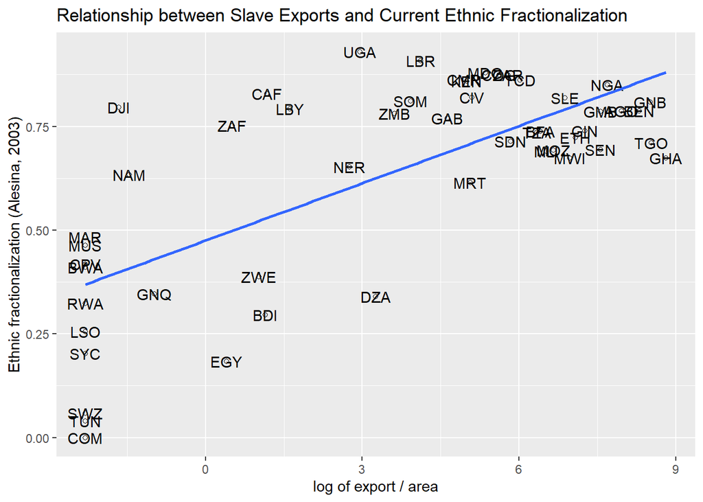

```r
ggplot(slave_data, aes(x=ln_export_area, y=ethnic_fractionalization))+
  geom_point(shape=1)+
  geom_text(label=slave_data$isocode)+
  geom_smooth(method=lm, se=FALSE)+
  ggtitle("Relationship between Slave Exports and Current Ethnic Fractionalization")+
  xlab("log of export / area")+
  ylab("Ethnic fractionalization (Alesina, 2003)")
```

## 2.6 Figure VII: slave trades is linked to the weakening and underdevelopment of states

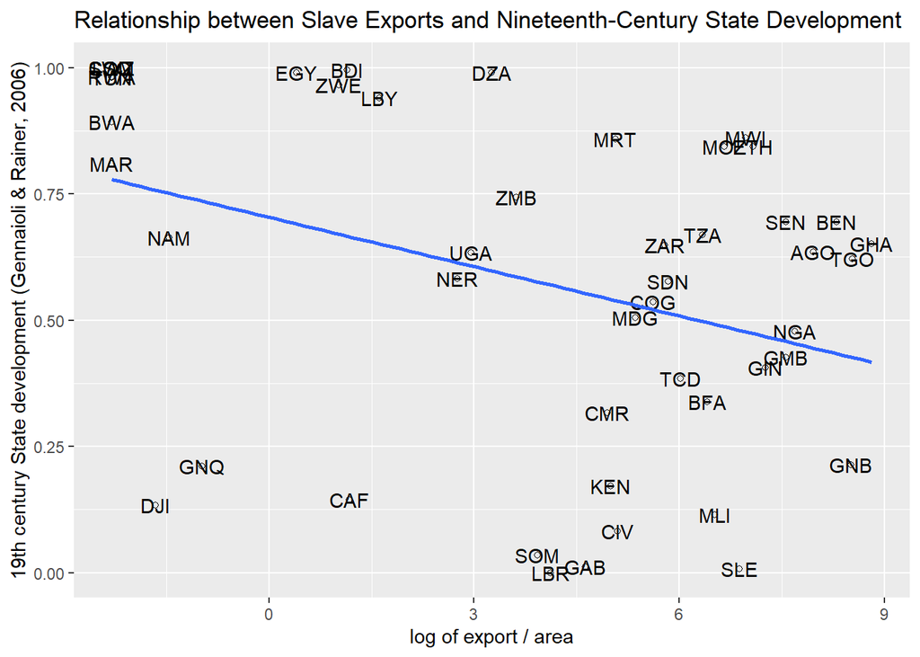

```r
ggplot(slave_data, aes(x=ln_export_area, y=state_dev))+
  geom_point(shape=1)+
  geom_text(label=slave_data$isocode)+
  geom_smooth(method=lm, se=FALSE)+
  ggtitle("Relationship between Slave Exports and Nineteenth-Century State Development")+
  xlab("log of export / area")+
  ylab("19th century State development (Gennaioli & Rainer, 2006)")
```

# 3 Critique

I think there are some aspects that weaken the results, and thus leave room for imprevement. These are the following:

- weak instrument
- might be more correct to use heteroskedasticity-robust standard errors

Let’s explore them individually.

## 3.1 weak instrument

Whit IV regressions there are 3 main diagnostics tests:

1. Weak instruments: The null hypothesis is that we have weak instruments, so a rejection means our instruments are not weak, which is good;
2. Wu-Hausman: Test for consistency. When we reject, it means OLS is not consistent, suggesting endogeneity is present;
3. Sargan test: Used when there is more than one instrument. If the null is rejected, it means that at least one of our instruments is invalid, and possibly all of them;

In Table IV the author reports only the last two above mentioned tests, but if we compute the Weak instrument test for the model in column (3) we get a pvalue of 0.53 implying that the instruments are weak in this scenario.

```r
round(summary(ivreg3, diagnostics = TRUE)$diagnostics[1,4], digits=2) #Weak instrument test pvalue
```

```
## [1] 0.53
```

In defense of the author, I would say that this is not enough to undermine his overall results.

## 3.2 Heteroskedasticity-Consistent standard errors

Just like in multiple regression it is important to compute heteroskedasticity-robust standard errors. However, throughout the paper the author never used robust standard errors.

Let’s rebuilt Tables III and IV this time taking into account HC standard errors:

```r
#Modify Table III by taking into account Heteroskedasticity-Consistent standard errors using vcovHC()
se1<-coeftest(ols1, vcov = vcovHC, type = "HC1")
se2<-coeftest(ols2, vcov = vcovHC, type = "HC1")
se3<-coeftest(ols3, vcov = vcovHC, type = "HC1")
se4<-coeftest(ols4, vcov = vcovHC, type = "HC1")
se5<-coeftest(ols5, vcov = vcovHC, type = "HC1")
se6<-coeftest(ols6, vcov = vcovHC, type = "HC1")
stargazer(se1,se2,se3,se4,se5,se6,
          header = FALSE,
          digits = 3,
          title="Relationship between Slave Exports and Income - corrected for HC std.err.",
          type = "html",
          dep.var.labels.include = FALSE,
          dep.var.caption =
            "Dependent variable is log real per capita GDP in 2000, ln y",
          omit=c('colony1','colony2','colony3','colony4','colony5','colony6','colony7','Constant'),
          add.lines=list(c('Colonizer fixed effects',"Yes","Yes","Yes","Yes","Yes","Yes")))
```

**Relationship between Slave Exports and Income - corrected for HC std.err.**

|  | Dependent variable is log real per capita GDP in 2000, ln y |  |  |  |  |  |
| --- | --- | --- | --- | --- | --- | --- |
|  | (1) | (2) | (3) | (4) | (5) | (6) |
| ln_export_area | -0.112*** | -0.076*** | -0.108*** | -0.085** | -0.103*** | -0.128*** |
|  | (0.027) | (0.027) | (0.037) | (0.033) | (0.029) | (0.031) |
| abs_latitude |  | 0.016 | -0.005 | 0.019 | 0.023 | 0.006 |
|  |  | (0.018) | (0.021) | (0.015) | (0.015) | (0.015) |
| longitude |  | 0.0005 | -0.007 | -0.004 | -0.004 | -0.009 |
|  |  | (0.006) | (0.006) | (0.005) | (0.006) | (0.006) |
| rain_min |  | -0.001 | 0.008 | 0.0001 | -0.001 | -0.002 |
|  |  | (0.011) | (0.007) | (0.007) | (0.008) | (0.007) |
| humid_max |  | 0.009 | 0.008 | 0.009 | 0.015 | 0.013 |
|  |  | (0.009) | (0.010) | (0.011) | (0.009) | (0.009) |
| low_temp |  | -0.019 | -0.039 | -0.005 | -0.015 | -0.037 |
|  |  | (0.031) | (0.028) | (0.030) | (0.027) | (0.027) |
| ln_coastline_area |  | 0.085** | 0.092** | 0.095* | 0.082* | 0.083** |
|  |  | (0.036) | (0.041) | (0.049) | (0.044) | (0.037) |
| region_n |  |  |  | 0.382 | -0.304 |  |
|  |  |  |  | (0.379) | (0.392) |  |
| legor_fr |  |  |  | 0.755 | 0.643 | -0.141 |
|  |  |  |  | (0.456) | (0.427) | (0.483) |
| island_dum |  |  |  | -0.398 | -0.150 |  |
|  |  |  |  | (0.497) | (0.536) |  |
| islam |  |  |  | -0.008** | -0.006 | -0.003 |
|  |  |  |  | (0.003) | (0.004) | (0.003) |
| ln_avg_gold_pop |  |  |  |  | 0.011 | 0.014 |
|  |  |  |  |  | (0.014) | (0.014) |
| ln_avg_oil_pop |  |  |  |  | 0.078*** | 0.088*** |
|  |  |  |  |  | (0.026) | (0.025) |
| ln_avg_all_diamonds_pop |  |  |  |  | -0.039 | -0.048 |
|  |  |  |  |  | (0.051) | (0.048) |
| Colonizer fixed effects | Yes | Yes | Yes | Yes | Yes | Yes |
| *Note:* | p<0.1; p<0.05; p<0.01 |  |  |  |  |  |

```r
#Modify Table IV by taking into account Heteroskedasticity-Consistent standard errors using vcovHC()
model.lst = list(ivreg1, ivreg2, ivreg3, ivreg4)
model.lst2 = list(stage1_1, stage1_2, stage1_3, stage1_4)
stargazer(ivreg1, ivreg2, ivreg3, ivreg4,
          header = FALSE,
          digits = 3,
          title="Estimates of the relationship between Slave Exports and Income - corrected for HC std.err.",
          type = "html",
          dep.var.labels.include = FALSE,
          summary=TRUE,
          se=lapply(model.lst, function(x) sqrt(diag(sandwich::vcovHC(x, type = "HC1")))),
          dep.var.caption =
            "Second Stage. Dependent variable is log income in 2000, ln y",
          omit=c('colony1','colony2','colony3','colony4','colony5','colony6','colony7','Constant','abs_latitude',
                 'longitude','rain_min','humid_max','low_temp','ln_coastline_area'),
          add.lines=list(c('Colonizer fixed effects',"No","Yes","Yes","Yes"),
                         c('Geography controls','No','No','Yes','Yes'),
                         c('Restricted sample','No','No','No','Yes')))
```

**Estimates of the relationship between Slave Exports and Income - corrected for HC std.err.**

|  | Second Stage. Dependent variable is log income in 2000, ln y |  |  |  |
| --- | --- | --- | --- | --- |
|  | (1) | (2) | (3) | (4) |
| ln_export_area | -0.208*** | -0.201*** | -0.286* | -0.221** |
|  | (0.046) | (0.054) | (0.158) | (0.094) |
| Colonizer fixed effects | No | Yes | Yes | Yes |
| Geography controls | No | No | Yes | Yes |
| Restricted sample | No | No | No | Yes |
| Observations | 52 | 52 | 52 | 42 |
| R<sup>2</sup> | 0.127 | 0.342 | 0.041 | 0.511 |
| Adjusted R<sup>2</sup> | 0.110 | 0.220 | -0.322 | 0.284 |
| Residual Std. Error | 0.779 (df = 50) | 0.729 (df = 43) | 0.949 (df = 37) | 0.612 (df = 28) |
| *Note:* | p<0.1; p<0.05; p<0.01 |  |  |  |

```r
stargazer(stage1_1, stage1_2, stage1_3, stage1_4,
          header = FALSE,
          digits = 3,
          type = "html",
          dep.var.labels.include = FALSE,
          summary=TRUE,
          se=lapply(model.lst2, function(x) sqrt(diag(sandwich::vcovHC(x, type = "HC1")))),
          dep.var.caption =
            "First Stage. Dependent variable is slave exports, ln(exports/area)",
          omit=c('colony1','colony2','colony3','colony4','colony5','colony6','colony7','Constant','abs_latitude',
                 'longitude','rain_min','humid_max','low_temp','ln_coastline_area'),
          add.lines=list(c('Colonizer fixed effects',"No","Yes","Yes","Yes"),
                         c('Geography controls','No','No','Yes','Yes'),
                         c('Restricted sample','No','No','No','Yes')))
```

|  | First Stage. Dependent variable is slave exports, ln(exports/area) |  |  |  |
| --- | --- | --- | --- | --- |
|  | (1) | (2) | (3) | (4) |
| saharan_distance_minimum | -2.435*** | -3.001*** | -1.139 | -4.076** |
|  | (0.814) | (1.092) | (1.836) | (1.697) |
| atlantic_distance_minimum | -1.314*** | -1.741*** | -1.316* | -1.686** |
|  | (0.349) | (0.436) | (0.784) | (0.792) |
| indian_distance_minimum | -1.095*** | -1.426*** | -1.081 | -1.570* |
|  | (0.379) | (0.544) | (0.798) | (0.903) |
| red_sea_distance_minimum | -0.002 | -0.152 | -1.221 | 2.130 |
|  | (0.727) | (0.910) | (1.652) | (1.978) |
| Colonizer fixed effects | No | Yes | Yes | Yes |
| Geography controls | No | No | Yes | Yes |
| Restricted sample | No | No | No | Yes |
| Observations | 52 | 52 | 52 | 42 |
| R<sup>2</sup> | 0.279 | 0.396 | 0.477 | 0.720 |
| Adjusted R<sup>2</sup> | 0.218 | 0.230 | 0.216 | 0.540 |
| Residual Std. Error | 3.445 (df = 47) | 3.418 (df = 40) | 3.450 (df = 34) | 2.371 (df = 25) |
| F Statistic | 4.545*** (df = 4; 47) | 2.383** (df = 11; 40) | 1.824* (df = 17; 34) | 4.012*** (df = 16; 25) |
| *Note:* | p<0.1; p<0.05; p<0.01 |  |  |  |